# Airbnb prediction models

Oscar Leal 1903161

1/26/2020

## Data comes from http://insideairbnb.com/

### Task A

We first initiated the airbnb apartments data of London with the file *airbnb_london_cleaner.R* and *airbnb_london_manipulator.R* priorly provided.

The *cleaner* drops a few unnecesary variables like urls, it cleans the column names and create variables based on the amenities from the data. INPUT: listings.csv.gz OUTPUT: airbnb_london_cleaned.rds

The *manipulator* selects the property_type that fit in the description of **“… operating small and mid-size apartments hosting 1-6 guests. (City apartments, not houses.)”** it reduces a set of the minority (Serviced Apartment and Condominium) into Loft. It also creates factor variables, generalizes beds and policies. INPUT: airbnb_london_cleaned.rds OUTPUT: airbnb_london_not_hackney_workfile_adj.rds and airbnb_hackney_workfile_adj.rds

[output not shown]

[output not shown]

[output not shown]

[figure not shown]

Basic Statistical Descriptions

```r
# basic descr stat -------------------------------------------
skimr::skim(data)
```

Data summary

| Name | data |
| --- | --- |
| Number of rows | 49592 |
| Number of columns | 87 |
| _______________________ |  |
| Column type frequency: |  |
| factor | 15 |
| numeric | 72 |
| ________________________ |  |
| Group variables | None |

**Variable type: factor**

| skim_variable | n_missing | complete_rate | ordered | n_unique | top_counts |
| --- | --- | --- | --- | --- | --- |
| f_property_type | 0 | 1 | FALSE | 2 | Apa: 45633, Lof: 3959 |
| f_room_type | 0 | 1 | FALSE | 4 | Ent: 29876, Pri: 18752, Hot: 644, Sha: 320 |
| f_room_type2 | 0 | 1 | FALSE | 4 | Ent: 29876, Pri: 18752, .: 644, Sha: 320 |
| f_cancellation_policy | 0 | 1 | FALSE | 7 | 6: 21665, 1: 15239, 4: 12054, str: 627 |
| f_bed_type | 0 | 1 | FALSE | 3 | 5: 49176, Cou: 372, 2: 44 |
| f_neighbourhood_cleansed | 0 | 1 | FALSE | 32 | Wes: 6934, Tow: 6231, Ken: 4466, Cam: 4278 |
| d_is_business_travel_ready | 0 | 1 | FALSE | 1 | f: 49592 |
| d_cancellation_policy | 0 | 1 | FALSE | 7 | 6: 21665, 1: 15239, 4: 12054, str: 627 |
| neighbourhood_cleansed | 0 | 1 | FALSE | 32 | Wes: 6934, Tow: 6231, Ken: 4466, Cam: 4278 |
| cancellation_policy | 0 | 1 | FALSE | 7 | 6: 21665, 1: 15239, 4: 12054, str: 627 |
| room_type | 0 | 1 | FALSE | 4 | Ent: 29876, Pri: 18752, Hot: 644, Sha: 320 |
| property_type | 0 | 1 | FALSE | 2 | Apa: 45633, Lof: 3959 |
| f_bathroom | 66 | 1 | FALSE | 3 | 1: 43404, 2: 5876, 0: 246 |
| f_number_of_reviews | 1 | 1 | FALSE | 3 | 1: 34074, 0: 11069, 2: 4448 |
| f_minimum_nights | 1 | 1 | FALSE | 3 | 3: 18496, 1: 15686, 2: 15409 |

**Variable type: numeric**

| skim_variable | n_missing | complete_rate | mean | sd | p0 | p25 | p50 | p75 | p100 | hist |
| --- | --- | --- | --- | --- | --- | --- | --- | --- | --- | --- |
| usd_cleaning_fee | 0 | 1.00 | 1.023400e+02 | 8.373000e+01 | 7.00 | 50.00 | 85.00 | 1.250000e+02 | 9.990000e+02 | ▇▁▁▁▁ |
| usd_price_day | 0 | 1.00 | 1.023400e+02 | 8.373000e+01 | 7.00 | 50.00 | 85.00 | 1.250000e+02 | 9.990000e+02 | ▇▁▁▁▁ |
| p_host_response_rate | 15608 | 0.69 | 9.352000e+01 | 1.662000e+01 | 0.00 | 96.00 | 100.00 | 1.000000e+02 | 1.000000e+02 | ▁▁▁▁▇ |
| n_accommodates | 0 | 1.00 | 2.710000e+00 | 1.150000e+00 | 1.00 | 2.00 | 2.00 | 4.000000e+00 | 5.000000e+00 | ▂▇▂▅▁ |
| n_bathrooms | 65 | 1.00 | 1.160000e+00 | 3.700000e-01 | 0.00 | 1.00 | 1.00 | 1.000000e+00 | 1.050000e+01 | ▇▁▁▁▁ |
| n_review_scores_rating | 12016 | 0.76 | 9.227000e+01 | 1.030000e+01 | 20.00 | 90.00 | 95.00 | 1.000000e+02 | 1.000000e+02 | ▁▁▁▁▇ |
| n_number_of_reviews | 0 | 1.00 | 1.759000e+01 | 3.653000e+01 | 0.00 | 1.00 | 5.00 | 1.800000e+01 | 6.160000e+02 | ▇▁▁▁▁ |
| n_guests_included | 0 | 1.00 | 1.440000e+00 | 9.000000e-01 | 1.00 | 1.00 | 1.00 | 2.000000e+00 | 1.600000e+01 | ▇▁▁▁▁ |
| n_reviews_per_month | 11069 | 0.78 | 1.220000e+00 | 1.400000e+00 | 0.01 | 0.26 | 0.75 | 1.660000e+00 | 2.013000e+01 | ▇▁▁▁▁ |
| n_extra_people | 0 | 1.00 | 7.210000e+00 | 1.405000e+01 | 0.00 | 0.00 | 0.00 | 1.000000e+01 | 2.470000e+02 | ▇▁▁▁▁ |
| n_minimum_nights | 0 | 1.00 | 4.280000e+00 | 1.548000e+01 | 1.00 | 1.00 | 2.00 | 3.000000e+00 | 1.125000e+03 | ▇▁▁▁▁ |
| n_beds | 80 | 1.00 | 1.440000e+00 | 7.500000e-01 | 0.00 | 1.00 | 1.00 | 2.000000e+00 | 1.300000e+01 | ▇▁▁▁▁ |
| n_days_since | 11069 | 0.78 | 6.930000e+02 | 5.860100e+02 | 0.00 | 199.00 | 539.00 | 1.039000e+03 | 3.607000e+03 | ▇▃▁▁▁ |
| d_calculated_host_listings_count | 0 | 1.00 | 1.843000e+01 | 8.863000e+01 | 1.00 | 1.00 | 1.00 | 5.000000e+00 | 9.990000e+02 | ▇▁▁▁▁ |
| d_calculated_host_listings_count_entire_homes | 0 | 1.00 | 1.524000e+01 | 8.696000e+01 | 0.00 | 0.00 | 1.00 | 3.000000e+00 | 9.960000e+02 | ▇▁▁▁▁ |
| d_calculated_host_listings_count_private_rooms | 0 | 1.00 | 2.190000e+00 | 1.068000e+01 | 0.00 | 0.00 | 0.00 | 1.000000e+00 | 1.640000e+02 | ▇▁▁▁▁ |
| d_calculated_host_listings_count_shared_rooms | 0 | 1.00 | 3.000000e-02 | 6.100000e-01 | 0.00 | 0.00 | 0.00 | 0.000000e+00 | 1.900000e+01 | ▇▁▁▁▁ |
| d_reviews_per_month | 11069 | 0.78 | 1.220000e+00 | 1.400000e+00 | 0.01 | 0.26 | 0.75 | 1.660000e+00 | 2.013000e+01 | ▇▁▁▁▁ |
| d_toilet | 0 | 1.00 | 1.000000e-02 | 1.000000e-01 | 0.00 | 0.00 | 0.00 | 0.000000e+00 | 1.000000e+00 | ▇▁▁▁▁ |
| d_24hourcheckin | 0 | 1.00 | 7.000000e-02 | 2.500000e-01 | 0.00 | 0.00 | 0.00 | 0.000000e+00 | 1.000000e+00 | ▇▁▁▁▁ |
| d_accessibleheightbed | 0 | 1.00 | 2.000000e-02 | 1.500000e-01 | 0.00 | 0.00 | 0.00 | 0.000000e+00 | 1.000000e+00 | ▇▁▁▁▁ |
| d_accessibleheighttoilet | 0 | 1.00 | 2.000000e-02 | 1.300000e-01 | 0.00 | 0.00 | 0.00 | 0.000000e+00 | 1.000000e+00 | ▇▁▁▁▁ |
| d_airconditioning | 0 | 1.00 | 6.000000e-02 | 2.400000e-01 | 0.00 | 0.00 | 0.00 | 0.000000e+00 | 1.000000e+00 | ▇▁▁▁▁ |
| d_airpurifier | 0 | 1.00 | 0.000000e+00 | 1.000000e-02 | 0.00 | 0.00 | 0.00 | 0.000000e+00 | 1.000000e+00 | ▇▁▁▁▁ |
| d_alfrescobathtub | 0 | 1.00 | 0.000000e+00 | 0.000000e+00 | 0.00 | 0.00 | 0.00 | 0.000000e+00 | 1.000000e+00 | ▇▁▁▁▁ |
| d_amazonecho | 0 | 1.00 | 0.000000e+00 | 2.000000e-02 | 0.00 | 0.00 | 0.00 | 0.000000e+00 | 1.000000e+00 | ▇▁▁▁▁ |
| d_appletv | 0 | 1.00 | 0.000000e+00 | 0.000000e+00 | 0.00 | 0.00 | 0.00 | 0.000000e+00 | 0.000000e+00 | ▁▁▇▁▁ |
| d_babybath | 0 | 1.00 | 1.000000e-02 | 8.000000e-02 | 0.00 | 0.00 | 0.00 | 0.000000e+00 | 1.000000e+00 | ▇▁▁▁▁ |
| d_babymonitor | 0 | 1.00 | 0.000000e+00 | 4.000000e-02 | 0.00 | 0.00 | 0.00 | 0.000000e+00 | 1.000000e+00 | ▇▁▁▁▁ |
| d_babysitterrecommendations | 0 | 1.00 | 1.000000e-02 | 1.100000e-01 | 0.00 | 0.00 | 0.00 | 0.000000e+00 | 1.000000e+00 | ▇▁▁▁▁ |
| d_balcony | 0 | 1.00 | 0.000000e+00 | 4.000000e-02 | 0.00 | 0.00 | 0.00 | 0.000000e+00 | 1.000000e+00 | ▇▁▁▁▁ |
| d_bathtowel | 0 | 1.00 | 1.000000e-02 | 8.000000e-02 | 0.00 | 0.00 | 0.00 | 0.000000e+00 | 1.000000e+00 | ▇▁▁▁▁ |
| d_bathroomessentials | 0 | 1.00 | 1.000000e-02 | 9.000000e-02 | 0.00 | 0.00 | 0.00 | 0.000000e+00 | 1.000000e+00 | ▇▁▁▁▁ |
| d_bathtub | 0 | 1.00 | 8.000000e-02 | 2.700000e-01 | 0.00 | 0.00 | 0.00 | 0.000000e+00 | 1.000000e+00 | ▇▁▁▁▁ |
| d_bathtubwithbathchair | 0 | 1.00 | 0.000000e+00 | 3.000000e-02 | 0.00 | 0.00 | 0.00 | 0.000000e+00 | 1.000000e+00 | ▇▁▁▁▁ |
| d_bbqgrill | 0 | 1.00 | 2.000000e-02 | 1.300000e-01 | 0.00 | 0.00 | 0.00 | 0.000000e+00 | 1.000000e+00 | ▇▁▁▁▁ |
| d_beachessentials | 0 | 1.00 | 0.000000e+00 | 4.000000e-02 | 0.00 | 0.00 | 0.00 | 0.000000e+00 | 1.000000e+00 | ▇▁▁▁▁ |
| d_beachview | 0 | 1.00 | 0.000000e+00 | 1.000000e-02 | 0.00 | 0.00 | 0.00 | 0.000000e+00 | 1.000000e+00 | ▇▁▁▁▁ |
| d_beachfront | 0 | 1.00 | 0.000000e+00 | 2.000000e-02 | 0.00 | 0.00 | 0.00 | 0.000000e+00 | 1.000000e+00 | ▇▁▁▁▁ |
| d_bedlinens | 0 | 1.00 | 3.600000e-01 | 4.800000e-01 | 0.00 | 0.00 | 0.00 | 1.000000e+00 | 1.000000e+00 | ▇▁▁▁▅ |
| d_bedroomcomforts | 0 | 1.00 | 1.000000e-02 | 9.000000e-02 | 0.00 | 0.00 | 0.00 | 0.000000e+00 | 1.000000e+00 | ▇▁▁▁▁ |
| d_bidet | 0 | 1.00 | 0.000000e+00 | 1.000000e-02 | 0.00 | 0.00 | 0.00 | 0.000000e+00 | 1.000000e+00 | ▇▁▁▁▁ |
| d_bodysoap | 0 | 1.00 | 1.000000e-02 | 8.000000e-02 | 0.00 | 0.00 | 0.00 | 0.000000e+00 | 1.000000e+00 | ▇▁▁▁▁ |
| d_breakfast | 0 | 1.00 | 1.100000e-01 | 3.100000e-01 | 0.00 | 0.00 | 0.00 | 0.000000e+00 | 1.000000e+00 | ▇▁▁▁▁ |
| d_breakfastbar | 0 | 1.00 | 0.000000e+00 | 0.000000e+00 | 0.00 | 0.00 | 0.00 | 0.000000e+00 | 0.000000e+00 | ▁▁▇▁▁ |
| d_breakfasttable | 0 | 1.00 | 0.000000e+00 | 4.000000e-02 | 0.00 | 0.00 | 0.00 | 0.000000e+00 | 1.000000e+00 | ▇▁▁▁▁ |
| d_buildingstaff | 0 | 1.00 | 2.000000e-02 | 1.500000e-01 | 0.00 | 0.00 | 0.00 | 0.000000e+00 | 1.000000e+00 | ▇▁▁▁▁ |
| d_buzzerwirelessintercom | 0 | 1.00 | 1.500000e-01 | 3.500000e-01 | 0.00 | 0.00 | 0.00 | 0.000000e+00 | 1.000000e+00 | ▇▁▁▁▂ |
| d_cabletv | 0 | 1.00 | 1.500000e-01 | 3.600000e-01 | 0.00 | 0.00 | 0.00 | 0.000000e+00 | 1.000000e+00 | ▇▁▁▁▂ |
| d_carbonmonoxidedetector | 0 | 1.00 | 5.700000e-01 | 4.900000e-01 | 0.00 | 0.00 | 1.00 | 1.000000e+00 | 1.000000e+00 | ▆▁▁▁▇ |
| d_cats | 0 | 1.00 | 1.000000e-02 | 1.000000e-01 | 0.00 | 0.00 | 0.00 | 0.000000e+00 | 1.000000e+00 | ▇▁▁▁▁ |
| d_ceilingfan | 0 | 1.00 | 0.000000e+00 | 2.000000e-02 | 0.00 | 0.00 | 0.00 | 0.000000e+00 | 1.000000e+00 | ▇▁▁▁▁ |
| d_ceilingfans | 0 | 1.00 | 0.000000e+00 | 0.000000e+00 | 0.00 | 0.00 | 0.00 | 0.000000e+00 | 0.000000e+00 | ▁▁▇▁▁ |
| d_ceilinghoist | 0 | 1.00 | 0.000000e+00 | 1.000000e-02 | 0.00 | 0.00 | 0.00 | 0.000000e+00 | 1.000000e+00 | ▇▁▁▁▁ |
| d_centralairconditioning | 0 | 1.00 | 0.000000e+00 | 1.000000e-02 | 0.00 | 0.00 | 0.00 | 0.000000e+00 | 1.000000e+00 | ▇▁▁▁▁ |
| d_changingtable | 0 | 1.00 | 1.000000e-02 | 7.000000e-02 | 0.00 | 0.00 | 0.00 | 0.000000e+00 | 1.000000e+00 | ▇▁▁▁▁ |
| d_charcoalbarbeque | 0 | 1.00 | 0.000000e+00 | 0.000000e+00 | 0.00 | 0.00 | 0.00 | 0.000000e+00 | 0.000000e+00 | ▁▁▇▁▁ |
| d_chefskitchen | 0 | 1.00 | 0.000000e+00 | 0.000000e+00 | 0.00 | 0.00 | 0.00 | 0.000000e+00 | 1.000000e+00 | ▇▁▁▁▁ |
| price | 0 | 1.00 | 1.023400e+02 | 8.373000e+01 | 7.00 | 50.00 | 85.00 | 1.250000e+02 | 9.990000e+02 | ▇▁▁▁▁ |
| ln_price | 0 | 1.00 | 4.400000e+00 | 6.600000e-01 | 1.95 | 3.91 | 4.44 | 4.830000e+00 | 6.910000e+00 | ▁▃▇▃▁ |
| n_accommodates2 | 0 | 1.00 | 8.660000e+00 | 6.840000e+00 | 1.00 | 4.00 | 4.00 | 1.600000e+01 | 2.500000e+01 | ▇▁▁▃▁ |
| ln_accommodates | 0 | 1.00 | 9.000000e-01 | 4.500000e-01 | 0.00 | 0.69 | 0.69 | 1.390000e+00 | 1.610000e+00 | ▂▁▇▂▆ |
| ln_accommodates2 | 0 | 1.00 | 1.010000e+00 | 7.900000e-01 | 0.00 | 0.48 | 0.48 | 1.920000e+00 | 2.590000e+00 | ▇▁▁▃▁ |
| ln_beds | 1506 | 0.97 | 3.000000e-01 | 4.000000e-01 | 0.00 | 0.00 | 0.00 | 6.900000e-01 | 2.560000e+00 | ▇▅▁▁▁ |
| ln_number_of_reviews | 0 | 1.00 | 1.840000e+00 | 1.460000e+00 | 0.00 | 0.69 | 1.79 | 2.940000e+00 | 6.420000e+00 | ▇▆▅▂▁ |
| ln_days_since | 11071 | 0.78 | 6.020000e+00 | 1.230000e+00 | 0.00 | 5.29 | 6.29 | 6.950000e+00 | 8.190000e+00 | ▁▁▃▇▇ |
| ln_days_since2 | 11071 | 0.78 | 3.778000e+01 | 1.340000e+01 | 0.00 | 28.02 | 39.56 | 4.825000e+01 | 6.709000e+01 | ▁▃▆▇▂ |
| ln_days_since3 | 11071 | 0.78 | 2.438200e+02 | 1.170000e+02 | 0.00 | 148.31 | 248.82 | 3.351300e+02 | 5.494800e+02 | ▃▆▇▆▁ |
| n_days_since2 | 11069 | 0.78 | 8.236507e+05 | 1.269360e+06 | 0.00 | 39601.00 | 290521.00 | 1.079521e+06 | 1.301045e+07 | ▇▁▁▁▁ |
| n_days_since3 | 11069 | 0.78 | 1.264217e+09 | 2.969692e+09 | 0.00 | 7880599.00 | 156590819.00 | 1.121622e+09 | 4.692869e+10 | ▇▁▁▁▁ |
| ln_review_scores_rating | 12016 | 0.76 | 4.520000e+00 | 1.600000e-01 | 3.00 | 4.50 | 4.55 | 4.610000e+00 | 4.610000e+00 | ▁▁▁▁▇ |
| n_accommodates_copy | 0 | 1.00 | 2.710000e+00 | 1.150000e+00 | 1.00 | 2.00 | 2.00 | 4.000000e+00 | 5.000000e+00 | ▂▇▂▅▁ |

```r
summary(data$price)
```

```
##    Min. 1st Qu.  Median    Mean 3rd Qu.    Max.
##     7.0    50.0    85.0   102.3   125.0   999.0
```

```r
Hmisc::describe(data$price)
```

```
## data$price
##        n  missing distinct     Info     Mean      Gmd      .05      .10
##    49592        0      563        1    102.3    74.91       29       35
##      .25      .50      .75      .90      .95
##       50       85      125      185      246
##
## lowest :   7   8  10  11  12, highest: 983 986 990 998 999
```

```r
describe(data$f_room_type)
```

```
## data$f_room_type
##        n  missing distinct
##    49592        0        4
##
## Value      Entire home/apt      Hotel room    Private room     Shared room
## Frequency            29876             644           18752             320
## Proportion           0.602           0.013           0.378           0.006
```

```r
describe(data$f_property_type)
```

```
## data$f_property_type
##        n  missing distinct
##    49592        0        2
##
## Value      Apartment      Loft
## Frequency      45633      3959
## Proportion      0.92      0.08
```

```r
table(data$f_number_of_reviews)
```

```
##
##     0     1     2
## 11069 34074  4448
```

Our variable selection for predicting for Hackney is:

```r
# Basic Variables inc neighnourhood
basic_vars <- c(
  "n_accommodates", "n_beds", "n_days_since",
  "f_property_type","f_room_type", "f_bathroom", "f_cancellation_policy", "f_bed_type",
  "f_neighbourhood_cleansed")

# reviews
reviews <- c("n_number_of_reviews" ,"n_review_scores_rating", "n_reviews_per_month")

# Dummy variables
amenities <-  grep("^d_.*", names(data), value = TRUE)

#interactions for the LASSO
# from ch14
X1  <- c("n_accommodates*f_property_type",  "f_room_type*f_property_type",  "f_room_type*d_balcony",
         "d_airconditioning*f_property_type", "d_cats*f_property_type", "d_breakfast*f_property_type")
# with boroughs
X2  <- c("f_property_type*f_neighbourhood_cleansed", "f_room_type*f_neighbourhood_cleansed",
         "n_accommodates*f_neighbourhood_cleansed" )
```

Results of RF model 1:

```r
rf_model_1
```

```
## Random Forest
##
## 29862 samples
##     9 predictor
##
## No pre-processing
## Resampling: Cross-Validated (5 fold)
## Summary of sample sizes: 18553, 18553, 18553, 18552, 18553
## Resampling results across tuning parameters:
##
##   mtry  min.node.size  RMSE      Rsquared   MAE
##   7      5             45.93449  0.4685108  26.07735
##   7     10             45.90580  0.4692144  26.07452
##   9      5             45.84195  0.4696485  25.98775
##   9     10             45.86003  0.4692695  25.99364
##
## Tuning parameter 'splitrule' was held constant at a value of variance
## RMSE was used to select the optimal model using the smallest value.
## The final values used for the model were mtry = 9, splitrule = variance
##  and min.node.size = 5.
```

Results of RF model 2:

```r
rf_model_2
```

```
## Random Forest
##
## 29862 samples
##    58 predictor
##
## No pre-processing
## Resampling: Cross-Validated (5 fold)
## Summary of sample sizes: 18088, 18089, 18087, 18089, 18091
## Resampling results across tuning parameters:
##
##   mtry  min.node.size  RMSE      Rsquared   MAE
##   10     5             42.89821  0.5351873  24.30084
##   10    10             42.98999  0.5334125  24.36583
##   12     5             42.74908  0.5374081  24.20424
##   12    10             42.88662  0.5346296  24.28782
##
## Tuning parameter 'splitrule' was held constant at a value of variance
## RMSE was used to select the optimal model using the smallest value.
## The final values used for the model were mtry = 12, splitrule = variance
##  and min.node.size = 5.
```

```r
summary(results)
```

```
##
## Call:
## summary.resamples(object = results)
##
## Models: model_1, model_2
## Number of resamples: 5
##
## MAE
##             Min.  1st Qu.   Median     Mean  3rd Qu.     Max. NA's
## model_1 25.25707 25.70625 25.86518 25.98775 26.53996 26.57029    0
## model_2 23.67629 23.84350 24.12983 24.20424 24.52454 24.84706    0
##
## RMSE
##             Min.  1st Qu.   Median     Mean  3rd Qu.     Max. NA's
## model_1 42.73144 45.13675 45.35393 45.84195 46.22253 49.76511    0
## model_2 38.82364 41.50347 41.69115 42.74908 44.46775 47.25938    0
##
## Rsquared
##              Min.   1st Qu.    Median      Mean   3rd Qu.      Max. NA's
## model_1 0.4322011 0.4550843 0.4620757 0.4696485 0.4776176 0.5212635    0
## model_2 0.4811035 0.5316511 0.5406543 0.5374081 0.5666192 0.5670125    0
```

```
##             RMSE
## Model A 45.84195
## Model B 42.74908
```

Variable importance

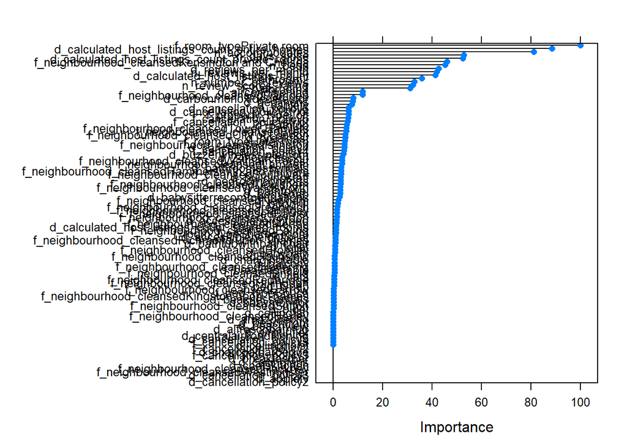

```r
# tohave a quick look
plot(varImp(rf_model_2))
```

Plot of importance a

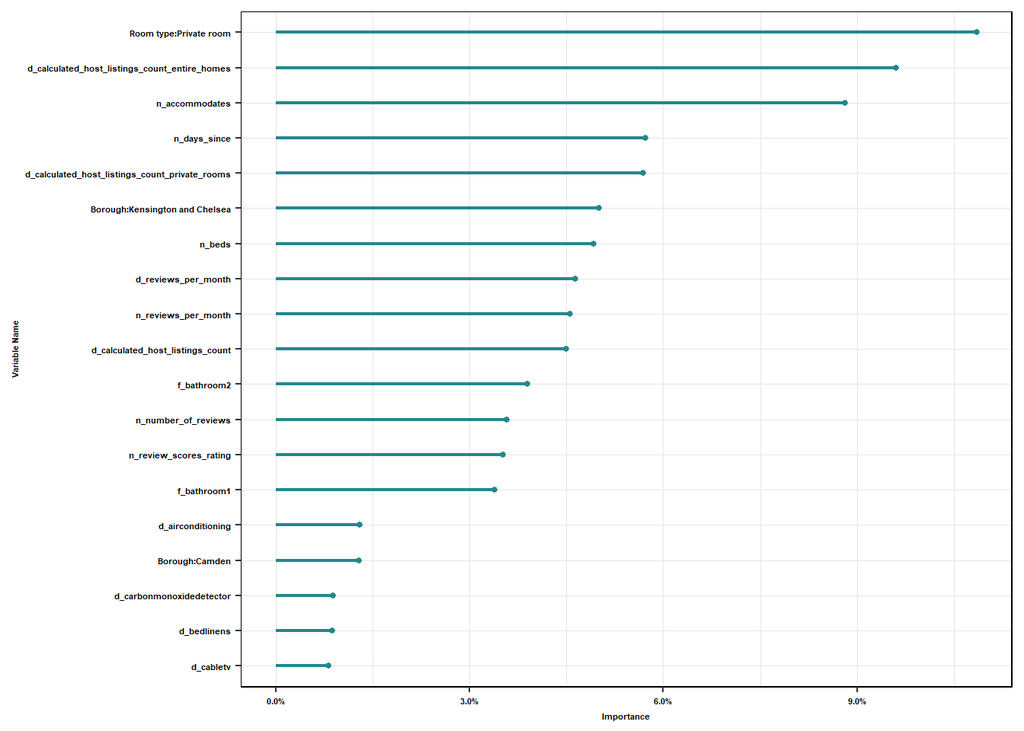

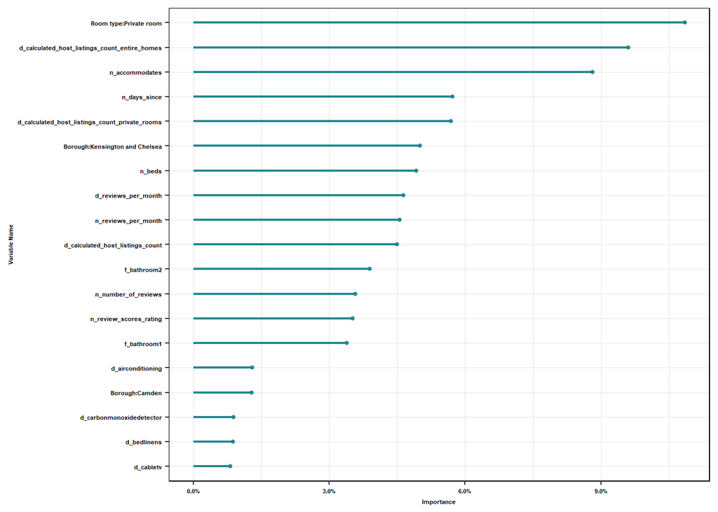

```r
rf_model_2_var_imp_plot
```

Plot of importance b

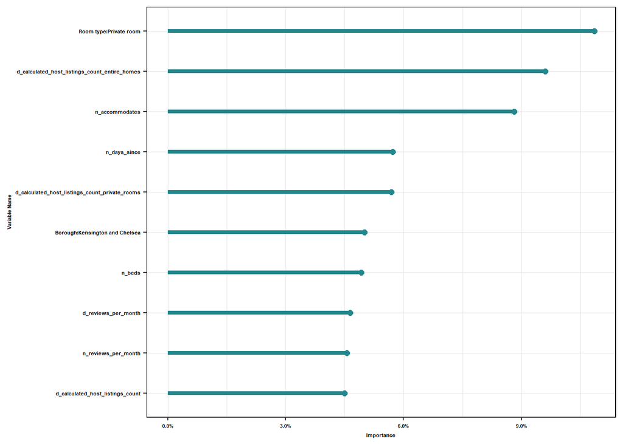

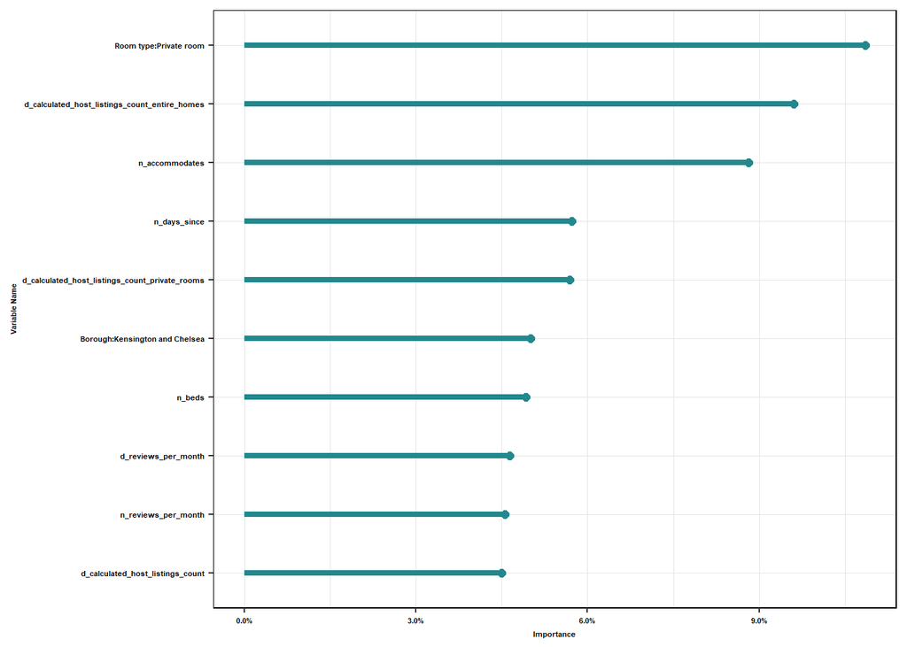

```r
rf_model_2_var_imp_plot_b
```

Importance plot of groups

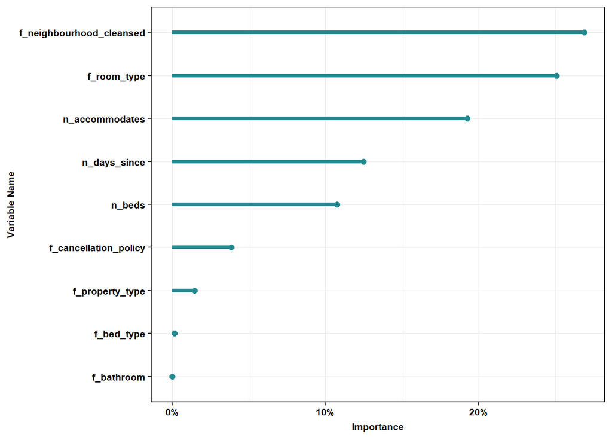

```r
rf_model_2_var_imp_grouped_plot
```

Plot of n_accommodates

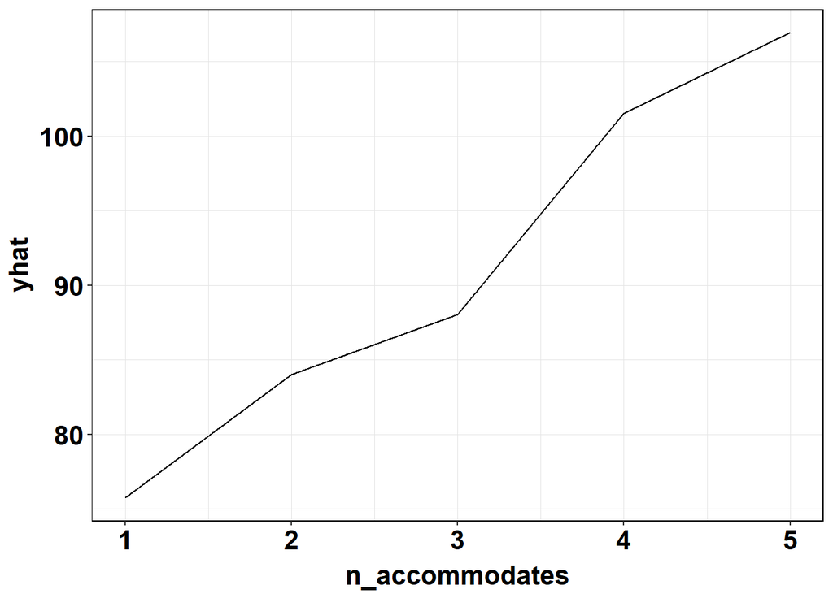

Plot of f_room_type

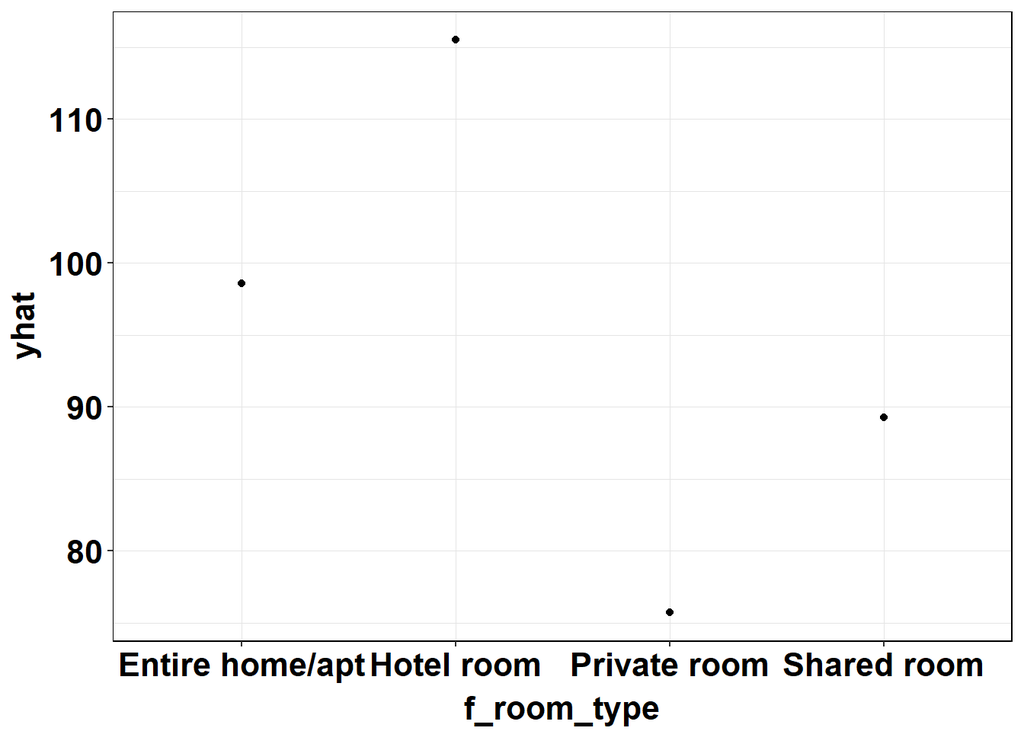

```
##    user  system elapsed
##    2.61    0.05    2.65
```

[output not shown]

[output not shown]

[output not shown]

```
##    user  system elapsed
##    8.65    0.84    9.50
```

```
##    user  system elapsed
##   11.16    0.08   11.25
```

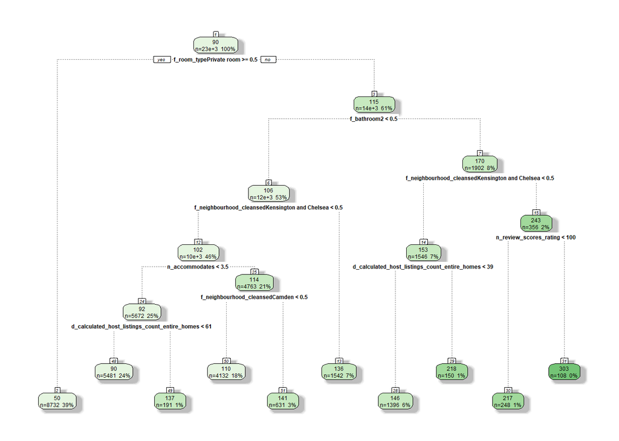

```
##    user  system elapsed
##  534.45    0.45  537.78
```

```
## Stochastic Gradient Boosting
##
## 29862 samples
##    58 predictor
##
## No pre-processing
## Resampling: Cross-Validated (5 fold)
## Summary of sample sizes: 18088, 18089, 18087, 18089, 18091
## Resampling results across tuning parameters:
##
##   shrinkage  interaction.depth  RMSE      Rsquared   MAE
##   0.05        1                 46.57300  0.4525238  26.89471
##   0.05        5                 43.31690  0.5227674  24.72361
##   0.05       10                 42.93674  0.5309144  24.35507
##   0.10        1                 45.61056  0.4711977  26.24854
##   0.10        5                 42.85370  0.5326004  24.40228
##   0.10       10                 42.94380  0.5307884  24.43049
##
## Tuning parameter 'n.trees' was held constant at a value of 250
## Tuning
##  parameter 'n.minobsinnode' was held constant at a value of 20
## RMSE was used to select the optimal model using the smallest value.
## The final values used for the model were n.trees = 250, interaction.depth =
##  5, shrinkage = 0.1 and n.minobsinnode = 20.
```

Results of all Algorithms used

```r
results <- resamples(final_models) %>% summary()
results
```

```
##
## Call:
## summary.resamples(object = .)
##
## Models: OLS, LASSO (model w/ interactions), CART, Random forest (smaller model), Random forest, GBM (basic tuning)
## Number of resamples: 5
##
## MAE
##                                   Min.  1st Qu.   Median     Mean  3rd Qu.
## OLS                           25.74728 25.82876 26.47095 26.44726 27.04849
## LASSO (model w/ interactions) 25.26332 25.39187 25.77509 25.83994 26.31966
## CART                          27.25495 27.89554 28.46864 28.30422 28.57058
## Random forest (smaller model) 25.25707 25.70625 25.86518 25.98775 26.53996
## Random forest                 23.67629 23.84350 24.12983 24.20424 24.52454
## GBM (basic tuning)            24.07575 24.14943 24.24052 24.40228 24.73097
##                                   Max. NA's
## OLS                           27.14085    0
## LASSO (model w/ interactions) 26.44977    0
## CART                          29.33140    0
## Random forest (smaller model) 26.57029    0
## Random forest                 24.84706    0
## GBM (basic tuning)            24.81475    0
##
## RMSE
##                                   Min.  1st Qu.   Median     Mean  3rd Qu.
## OLS                           41.49193 43.54789 45.44810 45.71466 48.03582
## LASSO (model w/ interactions) 41.05381 43.27223 45.01028 45.29367 47.52755
## CART                          43.94240 47.04942 48.74057 48.31768 50.21850
## Random forest (smaller model) 42.73144 45.13675 45.35393 45.84195 46.22253
## Random forest                 38.82364 41.50347 41.69115 42.74908 44.46775
## GBM (basic tuning)            39.41740 40.97782 42.04467 42.85370 44.57654
##                                   Max. NA's
## OLS                           50.04955    0
## LASSO (model w/ interactions) 49.60447    0
## CART                          51.63752    0
## Random forest (smaller model) 49.76511    0
## Random forest                 47.25938    0
## GBM (basic tuning)            47.25206    0
##
## Rsquared
##                                    Min.   1st Qu.    Median      Mean   3rd Qu.
## OLS                           0.4139087 0.4571757 0.4796904 0.4678648 0.4838162
## LASSO (model w/ interactions) 0.4242800 0.4687862 0.4896853 0.4776603 0.4903477
## CART                          0.3767346 0.4015000 0.4019521 0.4067307 0.4065662
## Random forest (smaller model) 0.4322011 0.4550843 0.4620757 0.4696485 0.4776176
## Random forest                 0.4811035 0.5316511 0.5406543 0.5374081 0.5666192
## GBM (basic tuning)            0.4779879 0.5328119 0.5425855 0.5326004 0.5547332
##                                    Max. NA's
## OLS                           0.5047329    0
## LASSO (model w/ interactions) 0.5152024    0
## CART                          0.4469004    0
## Random forest (smaller model) 0.5212635    0
## Random forest                 0.5670125    0
## GBM (basic tuning)            0.5548833    0
```

```r
# evaluate preferred model on the holdout set -----------------------------
RMSE(predict(cart_model, newdata = data_holdout), data_holdout[["price"]])
```

[output not shown]

Stats of Holdout with CART

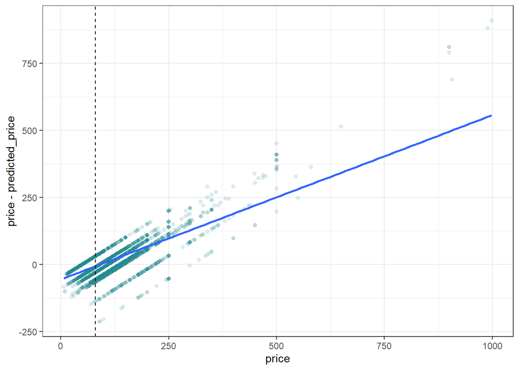

```
## data_holdout_w_prediction$n_accommodates
##        n  missing distinct     Info     Mean      Gmd
##     6778        0        5    0.878     2.79    1.233
##
## lowest : 1 2 3 4 5, highest: 1 2 3 4 5
##
## Value          1     2     3     4     5
## Frequency    586  3101   679  1975   437
## Proportion 0.086 0.458 0.100 0.291 0.064
##            Var.1     RMSE Mean.price RMSE.price
## 1 Apartment size       NA         NA         NA
## 2      large apt 66.14356  133.96103  0.4937523
## 3      small apt 44.44503   73.22584  0.6069583
## 4           Type       NA         NA         NA
## 5      Apartment 52.48560   93.06436  0.5639710
## 6        Borough       NA         NA         NA
## 7            All 53.19097   94.83889  0.5608561
```

```r
predictwithHoldoutOrOtherData(data_holdout, cart_model)
```

```r
#### Run for Predicting for Hackney-----------------------------------------
datahackney <- na.omit(datahackney) %>% mutate(predicted_price = predict(rf_model_2, newdata = na.omit(datahackney)))
RMSE(predict(cart_model, newdata = datahackney), datahackney[["price"]])
```

```
## [1] 45.23451
```

Stats of Hackney with CART

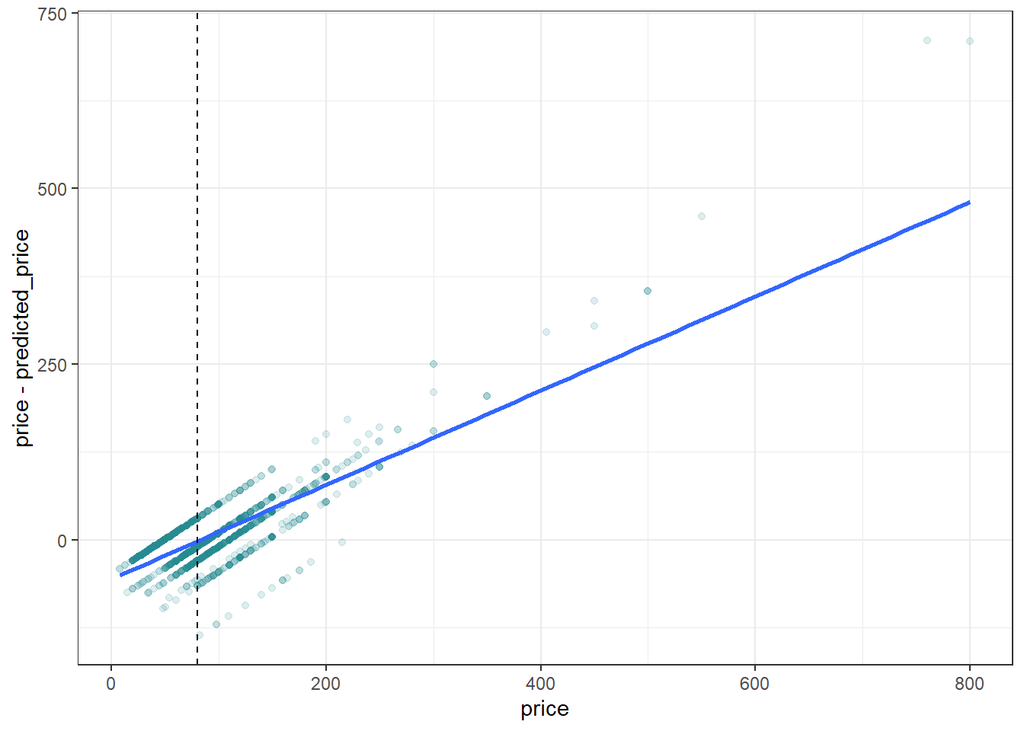

```
## data_holdout_w_prediction$n_accommodates
##        n  missing distinct     Info     Mean      Gmd
##     2152        0        5    0.841     2.67    1.158
##
## lowest : 1 2 3 4 5, highest: 1 2 3 4 5
##
## Value          1     2     3     4     5
## Frequency    193  1106   161   603    89
## Proportion 0.090 0.514 0.075 0.280 0.041
##            Var.1     RMSE Mean.price RMSE.price
## 1 Apartment size       NA         NA         NA
## 2      large apt 53.42730  118.46387  0.4510008
## 3      small apt 40.78040   70.25068  0.5804983
## 4           Type       NA         NA         NA
## 5      Apartment 45.20608   84.91260  0.5323836
## 6        Borough       NA         NA         NA
## 7            All 45.23451   85.75418  0.5274904
```

```r
predictwithHoldoutOrOtherData(datahackney, cart_model)
```

### Task B

The *cleaner* drops a few unnecesary variables like urls, it cleans the column names and create variables based on the amenities from the data. INPUT: listings.csv.gz (2) OUTPUT: airbnb_manchester_cleaned.rds, airbnb_bristol_cleaned.rds

The *manipulator* selects the property_type that fit in the description of **“… operating small and mid-size apartments hosting 1-6 guests. (City apartments, not houses.)”** it reduces a set of the minority (Serviced Apartment and Condominium) into Loft. It also creates factor variables, generalizes beds and policies.

Drops columns of neighbourhoods.

INPUT: airbnb_manchester_cleaned.rds, airbnb_bristol_cleaned.rds OUTPUT: airbnb_londonbristol_workfile_adj.rds and airbnb_manchester_workfile_adj.rds

```r
# Used area
area <- "londonbristol"
#area <- "london_not_hackney"
data <- readRDS(paste0("airbnb_", area, "_workfile_adj.rds")) %>%
  mutate_if(is.character, factor)

#datahackney <- readRDS("airbnb_hackney_only_workfile_adj.rds") %>% mutate_if(is.character, factor)


count_missing_values <- function(data) {
  num_missing_values <- map_int(data, function(x) sum(is.na(x)))
  num_missing_values[num_missing_values > 0]
}

count_missing_values(data)

# Sample definition and preparation ---------------------------------------

# We focus on normal apartments, n<8
data <- data %>% filter(n_accommodates < 6)

# copy a variable - purpose later, see at variable importance
data <- data %>% mutate(n_accommodates_copy = n_accommodates)
```

Basic descriptive stats

```r
# basic descr stat -------------------------------------------
#skimr::skim(data)
summary(data$price)
```

```
##    Min. 1st Qu.  Median    Mean 3rd Qu.    Max.
##    7.00   49.00   80.00   94.54  119.00  999.00
```

```r
Hmisc::describe(data$price)
```

```
## data$price
##        n  missing distinct     Info     Mean      Gmd      .05      .10
##    42658        0      492        1    94.54    67.11       28       34
##      .25      .50      .75      .90      .95
##       49       80      119      166      206
##
## lowest :   7   8  10  11  12, highest: 980 986 990 998 999
```

```r
#describe(data$f_room_type)
#describe(data$f_property_type)
table(data$f_number_of_reviews)
```

```
##
##     0     1     2
##  9545 29376  3736
```

For variable picking we excluded neighbourhoods, since we’re comparing data from different cities and they dont necessarily have neighborhoods marked. The rest stayed the same as the first task.

```r
# evaluate random forests -------------------------------------------------

results <- resamples(
  list(
    model_1  = rf_model_1,
    model_2  = rf_model_2
    # model_2b = rf_model_2b
  )
)
summary(results)
```

```
##
## Call:
## summary.resamples(object = results)
##
## Models: model_1, model_2
## Number of resamples: 5
##
## MAE
##             Min.  1st Qu.   Median     Mean  3rd Qu.     Max. NA's
## model_1 28.35788 28.51817 28.76130 28.83206 29.02427 29.49866    0
## model_2 25.61066 25.76476 26.13773 26.21968 26.61936 26.96592    0
##
## RMSE
##             Min.  1st Qu.   Median     Mean  3rd Qu.     Max. NA's
## model_1 46.95939 48.63136 48.91598 49.47079 49.79578 53.05145    0
## model_2 42.31105 43.76025 43.98709 45.36893 47.09018 49.69607    0
##
## Rsquared
##              Min.   1st Qu.    Median      Mean   3rd Qu.      Max. NA's
## model_1 0.3554004 0.3750934 0.3754700 0.3821705 0.3865436 0.4183452    0
## model_2 0.4230944 0.4728555 0.4801065 0.4762602 0.4849455 0.5202993    0
```

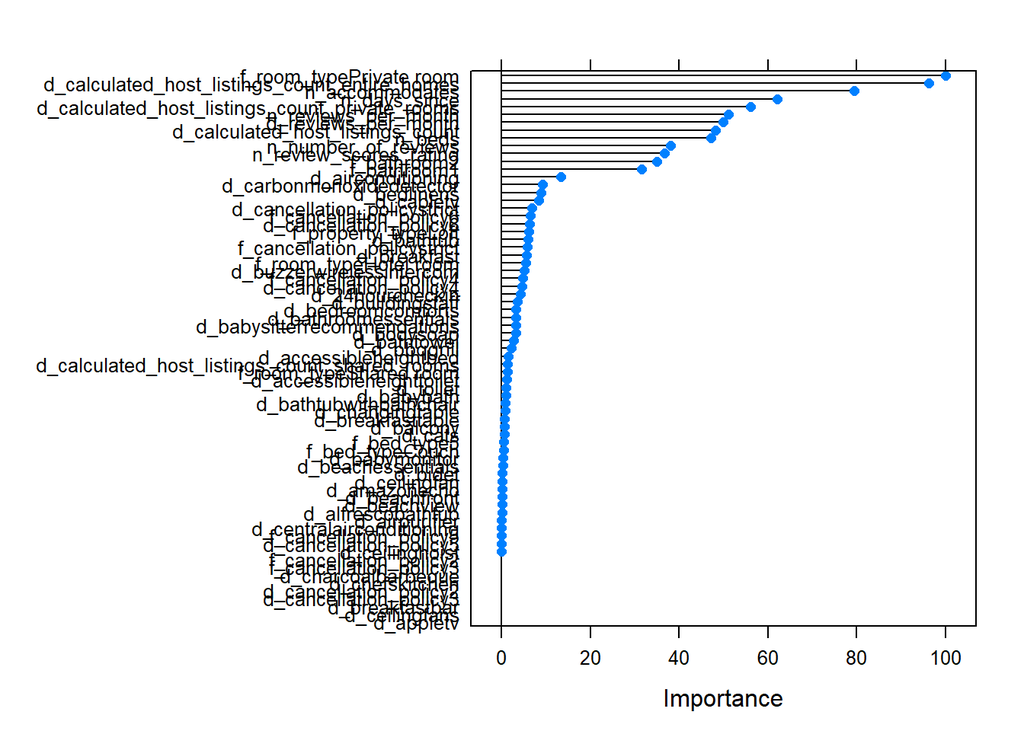

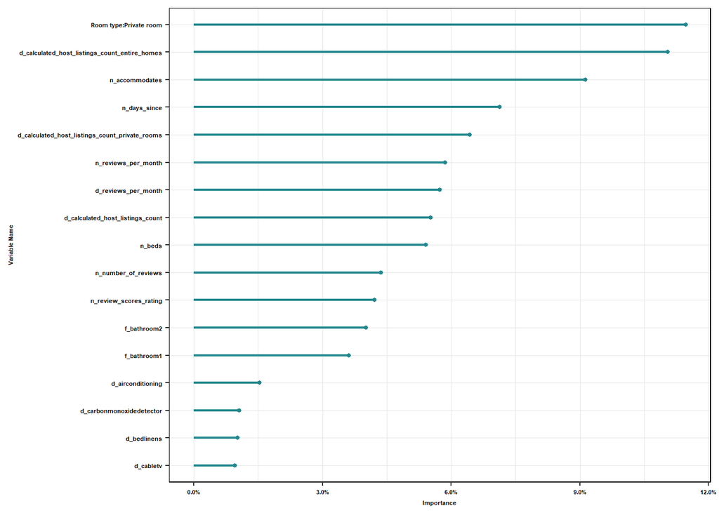

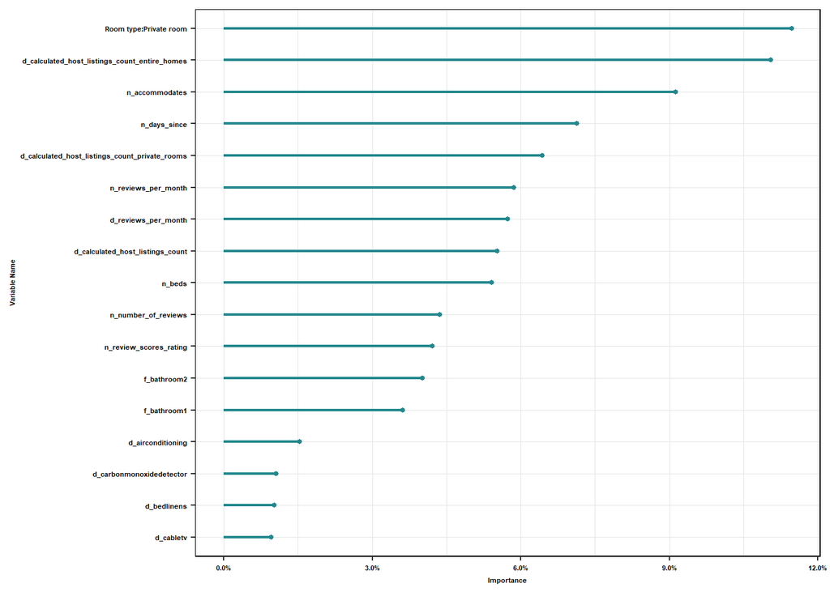

Fancy CART Plot

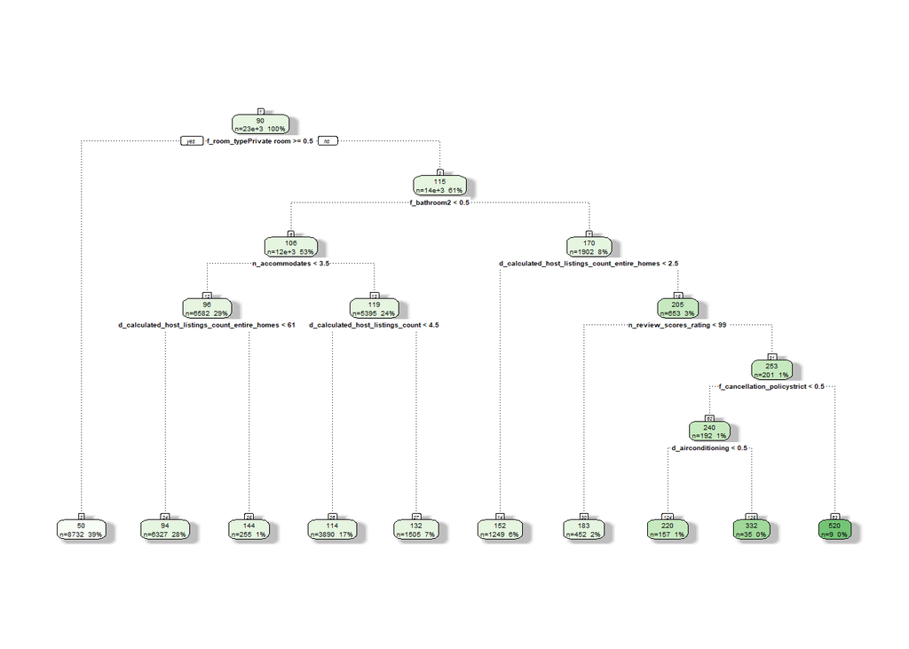

```r
fancyRpartPlot(cart_model$finalModel, sub = "")
```

```r
results <- resamples(final_models) %>% summary()
results
```

```
##
## Call:
## summary.resamples(object = .)
##
## Models: OLS, LASSO (model w/ interactions), CART, Random forest (smaller model), Random forest
## Number of resamples: 5
##
## MAE
##                                   Min.  1st Qu.   Median     Mean  3rd Qu.
## OLS                           27.65166 28.04054 28.37656 28.46084 28.92867
## LASSO (model w/ interactions) 27.56837 27.98503 28.29076 28.39758 28.87320
## CART                          28.03527 28.87459 29.06118 29.12968 29.52057
## Random forest (smaller model) 28.35788 28.51817 28.76130 28.83206 29.02427
## Random forest                 25.61066 25.76476 26.13773 26.21968 26.61936
##                                   Max. NA's
## OLS                           29.30677    0
## LASSO (model w/ interactions) 29.27054    0
## CART                          30.15682    0
## Random forest (smaller model) 29.49866    0
## Random forest                 26.96592    0
##
## RMSE
##                                   Min.  1st Qu.   Median     Mean  3rd Qu.
## OLS                           44.35624 46.45544 47.72250 48.26502 50.52379
## LASSO (model w/ interactions) 44.28205 46.46116 47.71507 48.24161 50.50918
## CART                          45.01892 47.84885 49.08863 49.27919 51.53461
## Random forest (smaller model) 46.95939 48.63136 48.91598 49.47079 49.79578
## Random forest                 42.31105 43.76025 43.98709 45.36893 47.09018
##                                   Max. NA's
## OLS                           52.26714    0
## LASSO (model w/ interactions) 52.24058    0
## CART                          52.90493    0
## Random forest (smaller model) 53.05145    0
## Random forest                 49.69607    0
##
## Rsquared
##                                    Min.   1st Qu.    Median      Mean   3rd Qu.
## OLS                           0.3607565 0.3995294 0.4127854 0.4066140 0.4265470
## LASSO (model w/ interactions) 0.3613528 0.4000487 0.4124445 0.4071844 0.4269248
## CART                          0.3451399 0.3749618 0.3781647 0.3815836 0.3928136
## Random forest (smaller model) 0.3554004 0.3750934 0.3754700 0.3821705 0.3865436
## Random forest                 0.4230944 0.4728555 0.4801065 0.4762602 0.4849455
##                                    Max. NA's
## OLS                           0.4334515    0
## LASSO (model w/ interactions) 0.4351512    0
## CART                          0.4168382    0
## Random forest (smaller model) 0.4183452    0
## Random forest                 0.5202993    0
```

RMSE of holdout as test set of Random forest model 2

```r
# evaluate preferred model on the holdout set -----------------------------
RMSE(predict(rf_model_2, newdata = data_holdout), data_holdout[["price"]])
```

```
## [1] 87.10837
```

RMSE of Manchester as test set of Random forest model 2

```r
#### RUN for Predicting for Manchester using Bristol + London---------------
manchester <- readRDS('airbnb_manchester_workfile_adj.rds')

RMSE(predict(rf_model_2, data = manchester), manchester[["price"]])
```

```
## [1] 101.8011
```

# Results:

In the second task, it was tricky to settle Manchester dataset in a compatible way to predict. This was done in the last moment, finalizing the result with a decision of Random Forest model 2, which performed the best. RMSE around 100 is definitely not the best solution, but it can be tuned furtherly with more computational power and more fine tuning of parameters (as the case with task A)